# Loan_approval_Prediction

### Catplot

To visualize the plot for the Gender and Marital Status of the applicant.

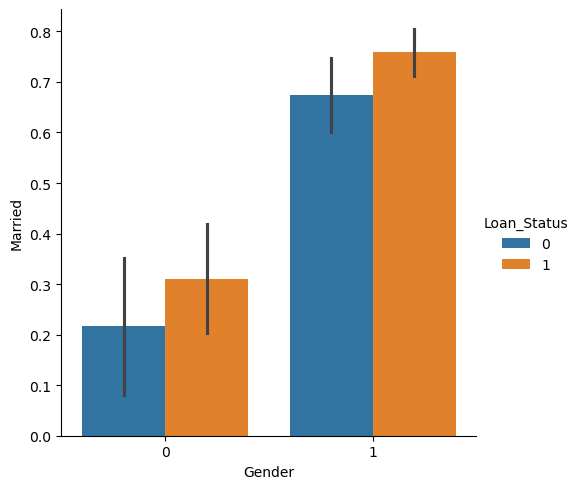

```python
sns.catplot(x="Gender", y="Married",
            hue="Loan_Status",
            kind="bar",
            data=df)
```

### Handling missing Values

```python
for col in df.columns:
  df[col] = df[col].fillna(df[col].mean())

df.isna().sum()
```

```
Gender               0
Married              0
Dependents           0
Education            0
Self_Employed        0
ApplicantIncome      0
CoapplicantIncome    0
LoanAmount           0
Loan_Amount_Term     0
Credit_History       0
Property_Area        0
Loan_Status          0
dtype: int64
```

There are no missing values in the dataset

### Data Splitting

```python
X = df.drop(['Loan_Status'],axis=1)
y = df['Loan_Status']
X.shape, y.shape

X_train, X_test, y_train, y_test = train_test_split(X,y, test_size=0.4, random_state=1)
X_train.shape, X_test.shape, y_train.shape, y_test.shape
```

```
((358, 11), (240, 11), (358,), (240,))
```

## Model Training

Being a classification problem using KNeighborsClassifiers, RandomForestClassifiers,Support Vector Classifiers (SVC) and Logistics Regression

```python
from sklearn.neighbors import KNeighborsClassifier
from sklearn.ensemble import RandomForestClassifier
from sklearn.svm import SVC
from sklearn.linear_model import LogisticRegression
from sklearn import metrics
import warnings
warnings.filterwarnings('ignore')
```

```python
knn = KNeighborsClassifier(n_neighbors=3)
rfc = RandomForestClassifier(n_estimators = 7,
                             criterion = 'entropy',
                             random_state =7)
svc = SVC()
lc = LogisticRegression()

# making predictions on the training set
for clf in (rfc, knn, svc,lc):
    clf.fit(X_train, y_train)
    y_pred = clf.predict(X_train)
    print("Accuracy score of ",
          clf.__class__.__name__,
          "=",100*metrics.accuracy_score(y_train,
                                         y_pred))
```

```
Accuracy score of  RandomForestClassifier = 98.04469273743017
Accuracy score of  KNeighborsClassifier = 78.49162011173185
Accuracy score of  SVC = 68.71508379888269
Accuracy score of  LogisticRegression = 80.44692737430168
```

#### Prediction on test data(Before SMOTE)

```python
before_smote = {}
after_smote = {}
```

```python
for clf in (rfc, knn, svc,lc):
    clf.fit(X_train, y_train)
    y_pred = clf.predict(X_test)
    accuracy = 100*metrics.accuracy_score(y_test, y_pred)
    before_smote [clf.__class__.__name__] = accuracy
    print (clf.__class__.__name__,'=',accuracy)
```

```
RandomForestClassifier = 82.5
KNeighborsClassifier = 63.74999999999999
SVC = 69.16666666666667
LogisticRegression = 80.83333333333333
```

Random Forest Classifier is giving the best accuracy of 82% for the testing dataset

```python
from sklearn.metrics import classification_report

print(classification_report(y_test, y_pred))
```

```
              precision    recall  f1-score   support

           0       0.81      0.48      0.60        73
           1       0.81      0.95      0.87       167

    accuracy                           0.81       240
   macro avg       0.81      0.72      0.74       240
weighted avg       0.81      0.81      0.79       240
```

Accracy is 0.81 which means that the model correctly predicts the output 81% of the time which is high. However the breakdown by class shows a significant peformance gap. The model performs very well for class 1(Majoity class - 167 samples ) with a Recall of 0.95,identifying 95% of all actual "1"cases . However the model struggles for class 0 (Minority class - 73 samples) with a Recall of ony 0.48 missing more than half(52%) of the total. The precision is 0.81 so when it does guess "0" , its usually corect , but it is far too conservative in making that prediction. Therefore, the model struggles to correctly identify negatives/non-approved loans.

```python
print(y_test.value_counts())
```

```
Loan_Status
1    167
0     73
Name: count, dtype: int64
```